International | France | USA

# Aux USA

Les données | Infos concernant les graphes | Les graphes depuis le "jour 0" | Évolution récente | Comparaison NY City vs IdF

### Les données

> - Les données sur le Covid-19 proviennent de [Johns Hopkins (github)](https://github.com/CSSEGISandData/COVID-19/tree/master/csse_covid_19_data/csse_covid_19_daily_reports) qui les exploite [ici](https://coronavirus.jhu.edu/map.html).
> - Les données objectives (population, etc) viennent de wikipedia.

```
données exploitées ici : du  03-05-2020  au  05-17-2020
```

```
pays comparatif (Italie) et total US, 2 derniers jours
```

|  | Italy | US |
| --- | --- | --- |
| 2020-05-16 | 31763 | 88754 |
| 2020-05-17 | 31908 | 89562 |

### Infos concernant les graphes

#### 0. Déterminer la date de "départ de l'épidémie" pour chaque état.

*Condition retenue :* date à laquelle le nombre de décès a dépassé 2 par million d'habitants.

#### 1. Déterminer les 12 états les plus touchés (après normalisation par leurs populations respectives)

| name | décès (par million d'hbts) |
| --- | --- |
| New York | 1451.3 |
| New Jersey | 1166.7 |
| Connecticut | 955.9 |
| Massachusetts | 841.1 |
| District of Columbia | 542.7 |
| Louisiana | 535.8 |
| Michigan | 489.7 |
| Rhode Island | 471.0 |
| Pennsylvania | 351.1 |
| Illinois | 329.6 |
| Maryland | 329.5 |
| Delaware | 297.8 |

#### 2. Déterminer les $n$ états les plus touchés (nombre absolu), totalisant ensemble plus de la moitié des décès aux US

| name | décès | % pop | % décès |
| --- | --- | --- | --- |
| Michigan | 4891 | 3.05 | 5.5 |
| Massachusetts | 5797 | 2.10 | 6.5 |
| New Jersey | 10363 | 2.71 | 11.6 |
| New York | 28232 | 5.94 | 31.5 |
| Autres états | 40279 | 86.20 | 45.0 |

### Les graphes : depuis le "jour 0"

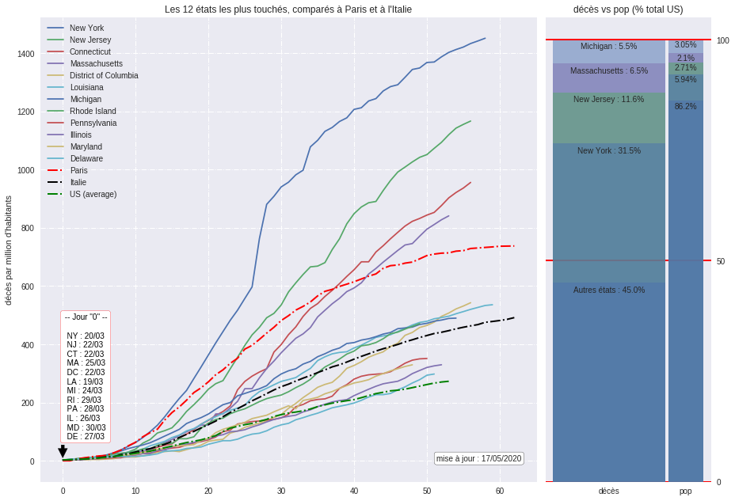

### Les graphes : évolution récente

Il s'agit de la comparaison du nombre de décès quotidiens (lissé sur $n$ jours) entre les deux dernières périodes de $n$ jours.

Les états dont le nom est en vert sont ceux pour lesquels l'évolution est positive (moins de cas dans la dernière période que dans la précédente).

```
On a choisi, n = 7 jours
```

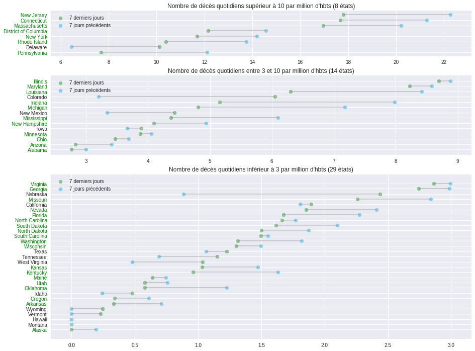

### Comparaison NY City / NY State (US) vs Paris / IdF (France)

*Données objectives.* (Wikipedia)

- **New York City** abrite une population de 8,399 millions d'habitants (en 2008), sur une superficie de 784 km2 soit une densité de 10 715 hab./km2.
- **L'état de New York** abrite 19 453 561 habitants (en 2008), sur une superficie de 141 300 km2 soit une densité de 138 hab./km2.
- **Paris** abrite 2 187 526 habitants (en 2017) sur une superficie de 105 km2, soit une densité de 20 755 hab./km2.
- **L'Île de France** est composée de : Paris (75), la Seine-et-Marne (77), les Yvelines (78), l'Essonne (91), les Hauts-de-Seine (92), la Seine-Saint-Denis (93), le Val-de-Marne (94), et le Val-d'Oise (95). Elle abrite 12 174 880 habitants (en 2017) sur une superficie de 12 011 km2, on a donc une densité de 1 014 hab./km2.

```
2 derniers jours :
```

|  | NYC | NYS | Paris | IDF |
| --- | --- | --- | --- | --- |
| 2020-05-16 | 20576 | 28049 | 1613 | 6710 |
| 2020-05-17 | 20720 | 28232 | 1614 | 6727 |

```
Remarque. Au 17/05/2020, pas d'info sur les décès en ehpad en IDF ! (0 décès en ehpad à Paris et 0 en ÎdF).
```

*Début de l'épidémie.* Date à laquelle il y a plus de 2 décès par million d'habitants :

- NYC, NYS : le 19 mars,
- Paris, IDF : le 18 mars.

À Paris il suffit de 5 décès, or il y en a déjà 14 le 18 mars. J'estime qu'on peut dater le début 2 jours plus tôt, le 16 mars. (Pour l'IDF, il faut au moins 25 décès et vu la courbe la date du 18 mars est possible.) Pour NY, on choisit le 18 mars (1.9 décès / millions d'hbts, alors qu'on est à 4 le lendemain). Idem pour l'état de New York.

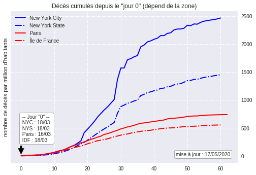

International << France < USA